# 산업공학특론I_13-14주차_산업데이터분석

2024-05-29

## [데이터 분석 개요]

### 1. 대상 데이터: 다단계 공정 데이터셋

(https://www.kaggle.com/datasets/supergus/multistage-continuousflow-manufacturing-process)

미시간 주 디트로이트 근처의 실제 생산 라인 내에서 여러 위치, 여러 생산 라인에 대하여 계측한 데이터

다양한 입력 데이터로부터 라인의 출력 특정 속성을 예측하기 위한 목적으로 수집

해당 공정 라인은 병렬 및 직렬 단계로 구성된 고속 연속 제조 공정으로, 다음과 같은 구조를 가짐

- Stage 1에서는 M1, M2, M3 기계가 병렬로 작동하며, 이들의 출력이 결합기로 전달
- 결합기에서 출력되는 Stage 1에 대한 예측치는 제작된 제품의 외부 표면을 둘러싼 15개의 위치에서 측정
- 다음으로, M4와 M5가 직렬로 처리하는 Stage 2로 이동
- M5 작동 후에는 동일한 15개의 위치에 대한 Stage 2의 측정이 이루어짐

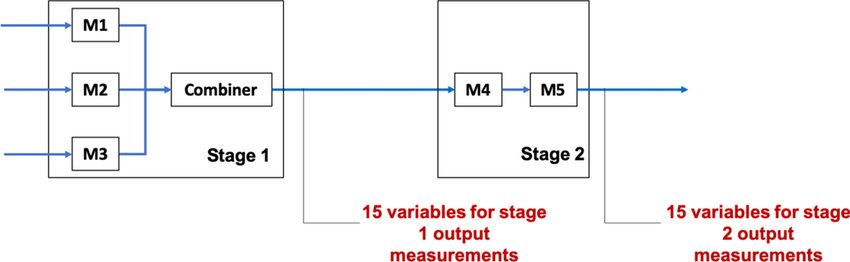

* Oleghe, O. (2020). A predictive noise correction methodology for manufacturing process datasets. Journal of Big Data, 7(1), 89.

### 2. 분석 절차

데이터 탐색 및 전처리 / 특징 추출 및 차원 축소 / 모델 학습 및 평가 순서로 3단계로 나누어 분석 진행

2단계 공정인 관계로 Stage 1에 대한 예측모델, Stage 2에 대한 예측모델을 2단계로 모델링할 것 (이 때, Stage 2의 결과는 Stage 1에 영향을 받음)

원래 Stage 1, Stage 2에 대한 예측값은 각각 15개씩이지만, 본 강의에서는 다변량 예측을 다루지 않는 관계로 각 Stage에 대한 평균값을 종속변수로 설정

팀별로 작업을 수행하며, 작업 코드는 팀장의 Github에 Push하여 공유, 통찰력 있는 분석 기법 발굴 시 모두와 공유

가이드로 제공된 참고문헌을 바탕으로 다양한 방법론으로 분석을 수행

## [데이터 분석]

### 1. 데이터 탐색 및 전처리

- 데이터의 전반적인 분포, 특징을 파악하기 위한 기초 분석 진행
- 다양한 전처리 방법론을 활용하여 데이터를 정제 (e.g. 필요없는 변수 및 이상치/노이즈 제거 또는 보정, 표준화 등)
- 데이터 전처리 순서 (학습, 테스트셋 분할 전후)를 꼼꼼히 살펴보고 진행할 것

```r
library(corrplot)
library(ggplot2)
library(caret)
# 데이터 로드 및 전처리
dat <- read.csv("E:/Course/2024_lec_rstudio/실습/프로젝트실습/산업공학특론I_13-14주차_데이터.csv")
head(dat)
```

```
##            time_stamp AmbientConditions.AmbientHumidity.U.Actual
## 1 2019-03-06 10:52:33                                      17.24
## 2 2019-03-06 10:52:34                                      17.24
## 3 2019-03-06 10:52:35                                      17.24
## 4 2019-03-06 10:52:36                                      17.24
## 5 2019-03-06 10:52:37                                      17.24
## 6 2019-03-06 10:52:38                                      17.24
##   AmbientConditions.AmbientTemperature.U.Actual Machine1.RawMaterial.Property1
## 1                                         23.53                          11.54
## 2                                         23.53                          11.54
## 3                                         23.53                          11.54
## 4                                         23.53                          11.54
## 5                                         23.53                          11.54
## 6                                         23.53                          11.54
##   Machine1.RawMaterial.Property2 Machine1.RawMaterial.Property3
```

[output cut: 405 more lines]

```r
# stage 1과 stage2로 분리
stage1_m1 <- grep("Machine1", colnames(dat), value = TRUE)
stage1_m2 <- grep("Machine2", colnames(dat), value = TRUE)
stage1_m3 <- grep("Machine3", colnames(dat), value = TRUE)
stage1_co <- grep("FirstStage", colnames(dat), value = TRUE)

stage2_m4 <- grep("Machine4", colnames(dat), value = TRUE)
stage2_m5 <- grep("Machine5", colnames(dat), value = TRUE)

print(summary(dat[stage1_m1]))
```

```
##  Machine1.RawMaterial.Property1 Machine1.RawMaterial.Property2
##  Min.   :11.54                  Min.   :200.0
##  1st Qu.:11.54                  1st Qu.:200.0
##  Median :11.54                  Median :200.0
##  Mean   :11.85                  Mean   :205.7
##  3rd Qu.:12.22                  3rd Qu.:201.0
##  Max.   :12.90                  Max.   :236.0
##  Machine1.RawMaterial.Property3 Machine1.RawMaterial.Property4
##  Min.   : 601.1                 Min.   :247.0
##  1st Qu.: 963.0                 1st Qu.:247.0
##  Median : 963.0                 Median :247.0
##  Mean   : 951.7                 Mean   :248.9
##  3rd Qu.:1027.4                 3rd Qu.:251.0
##  Max.   :1048.1                 Max.   :257.0
##  Machine1.RawMaterialFeederParameter.U.Actual
##  Min.   : 231.3
##  1st Qu.:1257.2
##  Median :1264.4
##  Mean   :1242.8
##  3rd Qu.:1273.5
##  Max.   :1331.8
##  Machine1.Zone1Temperature.C.Actual Machine1.Zone2Temperature.C.Actual
##  Min.   :71.90                      Min.   :71.30
##  1st Qu.:72.00                      1st Qu.:71.60
##  Median :72.00                      Median :72.00
##  Mean   :72.01                      Mean   :72.01
##  3rd Qu.:72.00                      3rd Qu.:72.40
##  Max.   :72.50                      Max.   :72.70
##  Machine1.MotorAmperage.U.Actual Machine1.MotorRPM.C.Actual
##  Min.   :44.40                   Min.   :10.39
##  1st Qu.:68.88                   1st Qu.:10.52
##  Median :71.98                   Median :10.73
##  Mean   :70.33                   Mean   :11.07
##  3rd Qu.:72.92                   3rd Qu.:11.77
##  Max.   :88.53                   Max.   :12.24
##  Machine1.MaterialPressure.U.Actual Machine1.MaterialTemperature.U.Actual
##  Min.   :359.5                      Min.   :76.30
##  1st Qu.:408.9                      1st Qu.:81.00
##  Median :417.0                      Median :81.30
##  Mean   :409.0                      Mean   :81.47
##  3rd Qu.:421.5                      3rd Qu.:81.80
##  Max.   :487.2                      Max.   :83.90
##  Machine1.ExitZoneTemperature.C.Actual
##  Min.   :69.70
##  1st Qu.:75.00
##  Median :75.00
##  Mean   :75.97
##  3rd Qu.:75.10
##  Max.   :80.00
```

```r
print(summary(dat[stage1_m2]))
```

```
##  Machine2.RawMaterial.Property1 Machine2.RawMaterial.Property2
##  Min.   :12.59                  Min.   :236.0
##  1st Qu.:12.85                  1st Qu.:241.0
##  Median :12.85                  Median :241.0
##  Mean   :12.79                  Mean   :239.9
##  3rd Qu.:12.85                  3rd Qu.:241.0
##  Max.   :12.85                  Max.   :241.0
##  Machine2.RawMaterial.Property3 Machine2.RawMaterial.Property4
##  Min.   :556.7                  Min.   :256.0
##  1st Qu.:556.7                  1st Qu.:256.0
##  Median :556.7                  Median :256.0
##  Mean   :566.4                  Mean   :256.2
##  3rd Qu.:556.7                  3rd Qu.:256.0
##  Max.   :601.1                  Max.   :257.0
##  Machine2.RawMaterialFeederParameter.U.Actual
##  Min.   :  0.0
##  1st Qu.:194.2
##  Median :203.3
##  Mean   :202.6
##  3rd Qu.:211.8
##  Max.   :266.5
##  Machine2.Zone1Temperature.C.Actual Machine2.Zone2Temperature.C.Actual
##  Min.   :68.67                      Min.   :67.78
##  1st Qu.:68.98                      1st Qu.:69.07
##  Median :68.99                      Median :69.09
##  Mean   :69.00                      Mean   :69.10
##  3rd Qu.:69.00                      3rd Qu.:69.09
##  Max.   :69.66                      Max.   :69.94
##  Machine2.MotorAmperage.U.Actual Machine2.MotorRPM.C.Actual
##  Min.   :71.56                   Min.   :13.82
##  1st Qu.:73.19                   1st Qu.:13.87
##  Median :73.44                   Median :13.90
##  Mean   :73.40                   Mean   :13.90
##  3rd Qu.:73.69                   3rd Qu.:13.92
##  Max.   :74.38                   Max.   :13.97
##  Machine2.MaterialPressure.U.Actual Machine2.MaterialTemperature.U.Actual
##  Min.   :218.9                      Min.   :68.80
##  1st Qu.:223.9                      1st Qu.:76.90
##  Median :226.1                      Median :77.00
##  Mean   :226.1                      Mean   :76.81
##  3rd Qu.:227.9                      3rd Qu.:77.10
##  Max.   :250.6                      Max.   :77.40
##  Machine2.ExitZoneTemperature.C.Actual
##  Min.   :59.6
##  1st Qu.:59.9
##  Median :60.0
##  Mean   :60.0
##  3rd Qu.:60.1
##  Max.   :60.5
```

```r
print(summary(dat[stage1_m3]))
```

```
##  Machine3.RawMaterial.Property1 Machine3.RawMaterial.Property2
##  Min.   :8.83                   Min.   :186.0
##  1st Qu.:8.83                   1st Qu.:186.0
##  Median :8.83                   Median :221.0
##  Mean   :9.09                   Mean   :205.6
##  3rd Qu.:9.02                   3rd Qu.:221.0
##  Max.   :9.86                   Max.   :221.0
##  Machine3.RawMaterial.Property3 Machine3.RawMaterial.Property4
##  Min.   :409.0                  Min.   :200
##  1st Qu.:421.2                  1st Qu.:200
##  Median :433.2                  Median :205
##  Mean   :425.0                  Mean   :203
##  3rd Qu.:433.2                  3rd Qu.:205
##  Max.   :433.2                  Max.   :205
##  Machine3.RawMaterialFeederParameter.U.Actual
##  Min.   :  0.0
##  1st Qu.:194.0
##  Median :202.9
##  Mean   :202.4
##  3rd Qu.:211.8
##  Max.   :259.1
##  Machine3.Zone1Temperature.C.Actual Machine3.Zone2Temperature.C.Actual
##  Min.   :77.28                      Min.   :77.7
##  1st Qu.:78.00                      1st Qu.:77.9
##  Median :78.00                      Median :78.0
##  Mean   :78.01                      Mean   :78.0
##  3rd Qu.:78.00                      3rd Qu.:78.1
##  Max.   :78.70                      Max.   :78.6
##  Machine3.MotorAmperage.U.Actual Machine3.MotorRPM.C.Actual
##  Min.   :321.2                   Min.   :11.96
##  1st Qu.:338.9                   1st Qu.:12.97
##  Median :342.9                   Median :13.35
##  Mean   :345.1                   Mean   :13.27
##  3rd Qu.:348.2                   3rd Qu.:13.63
##  Max.   :374.3                   Max.   :14.00
##  Machine3.MaterialPressure.U.Actual Machine3.MaterialTemperature.U.Actual
##  Min.   :235.1                      Min.   :65.30
##  1st Qu.:242.8                      1st Qu.:73.60
##  Median :247.5                      Median :75.10
##  Mean   :246.8                      Mean   :74.14
##  3rd Qu.:248.9                      3rd Qu.:75.30
##  Max.   :263.7                      Max.   :75.50
##  Machine3.ExitZoneTemperature.C.Actual
##  Min.   :64.80
##  1st Qu.:65.00
##  Median :65.00
##  Mean   :65.01
##  3rd Qu.:65.00
##  Max.   :65.20
```

```r
print(summary(dat[stage1_co]))
```

```
##  FirstStage.CombinerOperation.Temperature1.U.Actual
##  Min.   : 45.3
##  1st Qu.:104.2
##  Median :105.5
##  Mean   :108.9
##  3rd Qu.:115.2
##  Max.   :118.9
##  FirstStage.CombinerOperation.Temperature2.U.Actual
##  Min.   : 53.3
##  1st Qu.: 69.0
##  Median : 74.8
##  Mean   : 84.9
##  3rd Qu.:104.2
##  Max.   :115.2
##  FirstStage.CombinerOperation.Temperature3.C.Actual
##  Min.   :79.60
##  1st Qu.:80.00
##  Median :80.00
##  Mean   :80.00
##  3rd Qu.:80.10
##  Max.   :80.32
```

```r
print(summary(dat[stage2_m4]))
```

```
##  Machine4.Temperature1.C.Actual Machine4.Temperature2.C.Actual
##  Min.   :298.0                  Min.   :284.0
##  1st Qu.:360.0                  1st Qu.:359.0
##  Median :360.0                  Median :360.0
##  Mean   :360.1                  Mean   :360.1
##  3rd Qu.:360.0                  3rd Qu.:361.0
##  Max.   :393.0                  Max.   :396.0
##  Machine4.Pressure.C.Actual Machine4.Temperature3.C.Actual
##  Min.   :14.00              Min.   :268.0
##  1st Qu.:17.00              1st Qu.:321.0
##  Median :17.00              Median :324.0
##  Mean   :17.23              Mean   :322.6
##  3rd Qu.:18.00              3rd Qu.:325.0
##  Max.   :25.00              Max.   :327.0
##  Machine4.Temperature4.C.Actual Machine4.Temperature5.C.Actual
##  Min.   :14.00                  Min.   :260.0
##  1st Qu.:17.00                  1st Qu.:309.0
##  Median :17.00                  Median :311.0
##  Mean   :17.23                  Mean   :309.8
##  3rd Qu.:18.00                  3rd Qu.:311.0
##  Max.   :25.00                  Max.   :326.0
##  Machine4.ExitTemperature.U.Actual
##  Min.   : 35.0
##  1st Qu.:191.0
##  Median :192.0
##  Mean   :187.1
##  3rd Qu.:193.0
##  Max.   :216.0
```

```r
print(summary(dat[stage2_m5]))
```

```
##  Machine5.Temperature1.C.Actual Machine5.Temperature2.C.Actual
##  Min.   :309.4                  Min.   :289.7
##  1st Qu.:310.0                  1st Qu.:290.0
##  Median :310.0                  Median :290.0
##  Mean   :310.0                  Mean   :290.0
##  3rd Qu.:310.0                  3rd Qu.:290.0
##  Max.   :310.3                  Max.   :290.3
##  Machine5.Temperature3.C.Actual Machine5.Temperature4.C.Actual
##  Min.   :263.8                  Min.   :237.6
##  1st Qu.:270.0                  1st Qu.:241.9
##  Median :270.0                  Median :242.7
##  Mean   :269.7                  Mean   :242.7
##  3rd Qu.:270.0                  3rd Qu.:243.6
##  Max.   :270.0                  Max.   :245.0
##  Machine5.Temperature5.C.Actual Machine5.Temperature6.C.Actual
##  Min.   :242.9                  Min.   :62.80
##  1st Qu.:245.0                  1st Qu.:63.20
##  Median :245.0                  Median :63.40
##  Mean   :245.0                  Mean   :63.42
##  3rd Qu.:245.0                  3rd Qu.:63.60
##  Max.   :245.7                  Max.   :66.10
##  Machine5.ExitTemperature.U.Actual
##  Min.   : 45.4
##  1st Qu.:154.2
##  Median :155.6
##  Mean   :154.0
##  3rd Qu.:156.6
##  Max.   :159.2
```

```r
# 각 Stage1, Stage2의 Actual의 평균 산출
stage1_output <- c()
stage2_output <- c()

st1 <- c('Stage1.Output')
st2 <- c('Stage2.Output')

for (i in colnames(dat)) {
  for (j in st1) {
    if (grepl(j, i) & grepl('Actual', i)) {
      stage1_output <- c(stage1_output, i)
    }
  }
  for (j in st2) {
    if (grepl(j, i) & grepl('Actual', i)) {
      stage2_output <- c(stage2_output, i)
    }
  }
}


stage1_label <- rowMeans(dat[, stage1_output], na.rm = TRUE)
stage2_label <- rowMeans(dat[, stage2_output], na.rm = TRUE)

dat["stage1_y"] <- stage1_label
dat["stage2_y"] <- stage2_label


# 데이터의 Missing value 확인
sum_na <- sum(is.na(dat))
print(sum_na)
```

```
## [1] 0
```

```
##                                              Machine1.RawMaterial.Property1
## Machine1.RawMaterial.Property1                                   1.00000000
## Machine1.RawMaterial.Property2                                   0.79149431
## Machine1.RawMaterial.Property3                                  -0.48855177
## Machine1.RawMaterial.Property4                                   0.83027741
## Machine1.RawMaterialFeederParameter.U.Actual                    -0.06216874
## Machine1.Zone1Temperature.C.Actual                              -0.23059988
## Machine1.Zone2Temperature.C.Actual                              -0.02699814
## Machine1.MotorAmperage.U.Actual                                 -0.59609283
## Machine1.MotorRPM.C.Actual                                       0.65703159
## Machine1.MaterialPressure.U.Actual                              -0.82229792
## Machine1.MaterialTemperature.U.Actual                            0.08499947
## Machine1.ExitZoneTemperature.C.Actual                            0.08659878
## stage1_y                                                        -0.11889092
## stage2_y                                                        -0.07021125
##                                              Machine1.RawMaterial.Property2
## Machine1.RawMaterial.Property1                                  0.791494307
## Machine1.RawMaterial.Property2                                  1.000000000
## Machine1.RawMaterial.Property3                                 -0.901974645
## Machine1.RawMaterial.Property4                                  0.935115744
## Machine1.RawMaterialFeederParameter.U.Actual                    0.014332008
## Machine1.Zone1Temperature.C.Actual                             -0.164382351
## Machine1.Zone2Temperature.C.Actual                             -0.004443691
## Machine1.MotorAmperage.U.Actual                                -0.581848313
## Machine1.MotorRPM.C.Actual                                      0.632927418
## Machine1.MaterialPressure.U.Actual                             -0.867079326
## Machine1.MaterialTemperature.U.Actual                          -0.036090376
## Machine1.ExitZoneTemperature.C.Actual                           0.025918895
## stage1_y                                                       -0.076566695
## stage2_y                                                       -0.115384445
##                                              Machine1.RawMaterial.Property3
## Machine1.RawMaterial.Property1                                  -0.48855177
## Machine1.RawMaterial.Property2                                  -0.90197465
## Machine1.RawMaterial.Property3                                   1.00000000
## Machine1.RawMaterial.Property4                                  -0.81136179
## Machine1.RawMaterialFeederParameter.U.Actual                    -0.04981779
## Machine1.Zone1Temperature.C.Actual                               0.05363202
## Machine1.Zone2Temperature.C.Actual                              -0.01297165
## Machine1.MotorAmperage.U.Actual                                  0.41704407
## Machine1.MotorRPM.C.Actual                                      -0.41735510
```

[output cut: 140 more lines]

```
##                                                  stage1_y     stage2_y
## Machine1.RawMaterial.Property1               -0.118890918 -0.070211245
## Machine1.RawMaterial.Property2               -0.076566695 -0.115384445
## Machine1.RawMaterial.Property3                0.037797336  0.138832055
## Machine1.RawMaterial.Property4               -0.153376319 -0.144057969
## Machine1.RawMaterialFeederParameter.U.Actual -0.006208954  0.065646005
## Machine1.Zone1Temperature.C.Actual            0.032719691 -0.533396538
## Machine1.Zone2Temperature.C.Actual            0.015113990 -0.059863043
## Machine1.MotorAmperage.U.Actual               0.028545664  0.378744428
## Machine1.MotorRPM.C.Actual                   -0.288072934 -0.155331687
## Machine1.MaterialPressure.U.Actual            0.069616698  0.009543447
## Machine1.MaterialTemperature.U.Actual        -0.254743608  0.204191203
## Machine1.ExitZoneTemperature.C.Actual        -0.303483746 -0.150753886
## stage1_y                                      1.000000000  0.080429317
## stage2_y                                      0.080429317  1.000000000
```

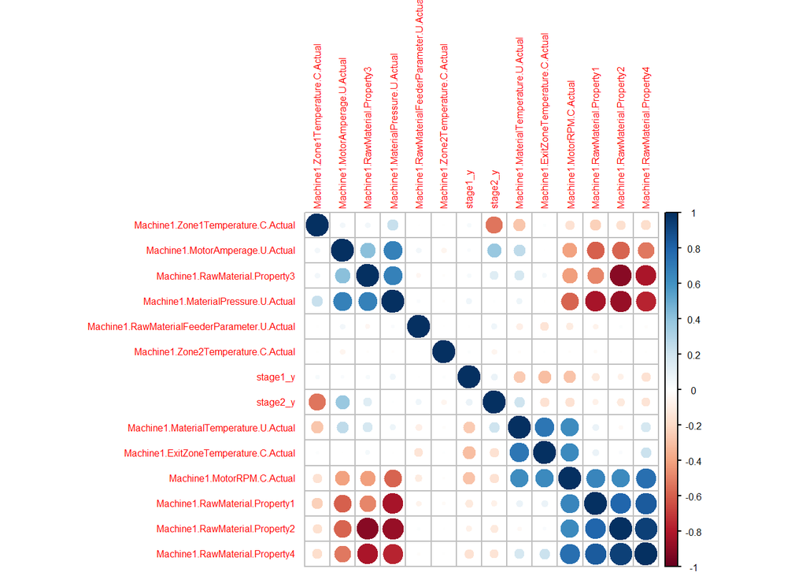

```r
# Correlation Matrix 계산
calculate_cor_matrix <- function(data) {
  # 표준편차 계산
  std_devs <- apply(data, 2, sd)

  # 표준편차가 0인 열 제거 <- 고정값으로 구성된 Stage2 Setpoint 제외
  data_clean <- data[, std_devs != 0]

  # 상관계수 행렬 계산
  cor_matrix <- cor(data_clean)

  return(cor_matrix)
}



draw_cor_plot <- function(col_list){

  i <- c(col_list, "stage1_y", "stage2_y")
  cor_dat <- calculate_cor_matrix(dat[,i])

  # 상관계수 행렬 출력
  print(cor_dat)

  # 상관계수 행렬 시각화
  corrplot(cor_dat, method = "circle", tl.cex = 0.5, cl.cex = 0.5,
           order = "hclust")
}

draw_cor_plot(stage1_m1)
```

```
##                                              Machine2.RawMaterial.Property1
## Machine2.RawMaterial.Property1                                  1.000000000
## Machine2.RawMaterial.Property2                                  1.000000000
## Machine2.RawMaterial.Property3                                 -1.000000000
## Machine2.RawMaterial.Property4                                 -1.000000000
## Machine2.RawMaterialFeederParameter.U.Actual                   -0.044282009
## Machine2.Zone1Temperature.C.Actual                              0.032088830
## Machine2.Zone2Temperature.C.Actual                             -0.068774639
## Machine2.MotorAmperage.U.Actual                                 0.720638786
## Machine2.MotorRPM.C.Actual                                     -0.001414282
## Machine2.MaterialPressure.U.Actual                             -0.480182716
## Machine2.MaterialTemperature.U.Actual                           0.527967236
## Machine2.ExitZoneTemperature.C.Actual                          -0.006936297
## stage1_y                                                       -0.235228531
## stage2_y                                                        0.134667542
##                                              Machine2.RawMaterial.Property2
## Machine2.RawMaterial.Property1                                  1.000000000
## Machine2.RawMaterial.Property2                                  1.000000000
## Machine2.RawMaterial.Property3                                 -1.000000000
## Machine2.RawMaterial.Property4                                 -1.000000000
## Machine2.RawMaterialFeederParameter.U.Actual                   -0.044282009
## Machine2.Zone1Temperature.C.Actual                              0.032088830
## Machine2.Zone2Temperature.C.Actual                             -0.068774639
## Machine2.MotorAmperage.U.Actual                                 0.720638786
## Machine2.MotorRPM.C.Actual                                     -0.001414282
## Machine2.MaterialPressure.U.Actual                             -0.480182716
## Machine2.MaterialTemperature.U.Actual                           0.527967236
## Machine2.ExitZoneTemperature.C.Actual                          -0.006936297
## stage1_y                                                       -0.235228531
## stage2_y                                                        0.134667542
##                                              Machine2.RawMaterial.Property3
## Machine2.RawMaterial.Property1                                 -1.000000000
## Machine2.RawMaterial.Property2                                 -1.000000000
## Machine2.RawMaterial.Property3                                  1.000000000
## Machine2.RawMaterial.Property4                                  1.000000000
## Machine2.RawMaterialFeederParameter.U.Actual                    0.044282009
## Machine2.Zone1Temperature.C.Actual                             -0.032088830
## Machine2.Zone2Temperature.C.Actual                              0.068774639
## Machine2.MotorAmperage.U.Actual                                -0.720638786
## Machine2.MotorRPM.C.Actual                                      0.001414282
```

[output cut: 140 more lines]

```
##                                                   stage1_y     stage2_y
## Machine2.RawMaterial.Property1               -0.2352285314  0.134667542
## Machine2.RawMaterial.Property2               -0.2352285314  0.134667542
## Machine2.RawMaterial.Property3                0.2352285314 -0.134667542
## Machine2.RawMaterial.Property4                0.2352285314 -0.134667542
## Machine2.RawMaterialFeederParameter.U.Actual  0.0358822957 -0.094954914
## Machine2.Zone1Temperature.C.Actual            0.0075052431 -0.171187380
## Machine2.Zone2Temperature.C.Actual           -0.0126876351 -0.196906087
## Machine2.MotorAmperage.U.Actual              -0.1782910485  0.207754550
## Machine2.MotorRPM.C.Actual                   -0.0009499836 -0.006378511
## Machine2.MaterialPressure.U.Actual            0.1041204995 -0.381570738
## Machine2.MaterialTemperature.U.Actual        -0.0770236873  0.710278627
## Machine2.ExitZoneTemperature.C.Actual        -0.0101449315 -0.014949526
## stage1_y                                      1.0000000000  0.080429317
## stage2_y                                      0.0804293171  1.000000000
```

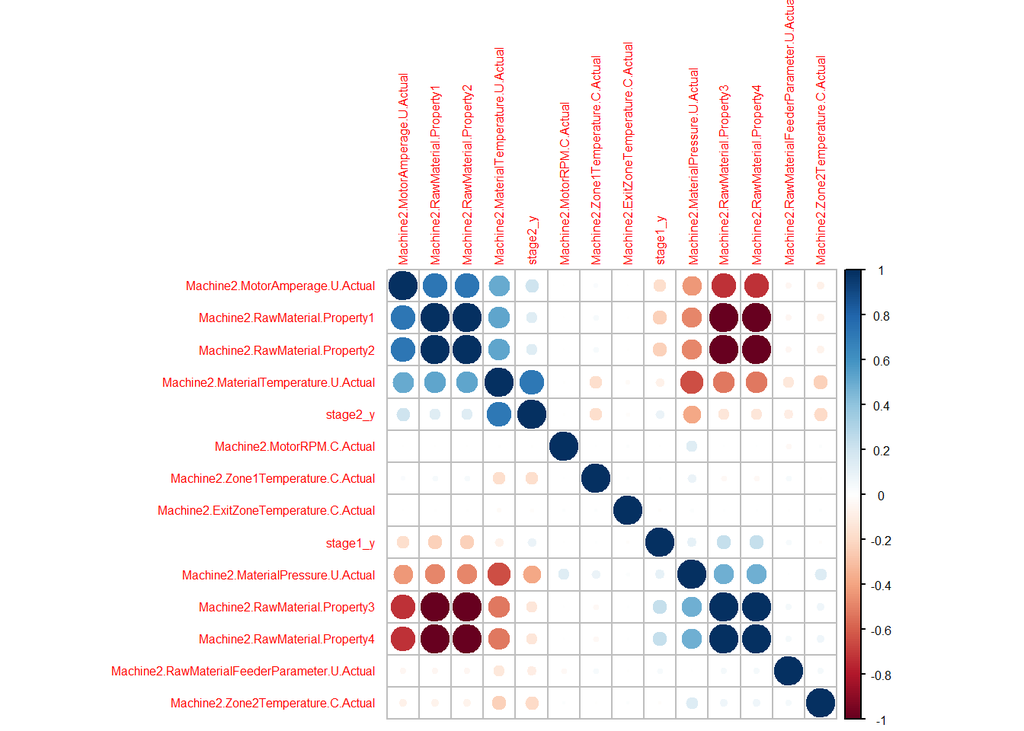

```r
draw_cor_plot(stage1_m2)
```

```
##                                              Machine3.RawMaterial.Property1
## Machine3.RawMaterial.Property1                                  1.000000000
## Machine3.RawMaterial.Property2                                 -0.596904953
## Machine3.RawMaterial.Property3                                 -0.937144648
## Machine3.RawMaterial.Property4                                 -0.432319801
## Machine3.RawMaterialFeederParameter.U.Actual                    0.018829680
## Machine3.Zone1Temperature.C.Actual                             -0.003567988
## Machine3.Zone2Temperature.C.Actual                              0.003443449
## Machine3.MotorAmperage.U.Actual                                 0.782277635
## Machine3.MotorRPM.C.Actual                                      0.336555699
## Machine3.MaterialPressure.U.Actual                              0.477337002
## Machine3.MaterialTemperature.U.Actual                           0.066658952
## Machine3.ExitZoneTemperature.C.Actual                           0.052298010
## stage1_y                                                        0.070016024
## stage2_y                                                        0.136213543
##                                              Machine3.RawMaterial.Property2
## Machine3.RawMaterial.Property1                                  -0.59690495
## Machine3.RawMaterial.Property2                                   1.00000000
## Machine3.RawMaterial.Property3                                   0.83934592
## Machine3.RawMaterial.Property4                                   0.98151485
## Machine3.RawMaterialFeederParameter.U.Actual                    -0.05247546
## Machine3.Zone1Temperature.C.Actual                              -0.13690921
## Machine3.Zone2Temperature.C.Actual                              -0.05948062
## Machine3.MotorAmperage.U.Actual                                 -0.14839457
## Machine3.MotorRPM.C.Actual                                      -0.70356614
## Machine3.MaterialPressure.U.Actual                               0.31168323
## Machine3.MaterialTemperature.U.Actual                            0.62139730
## Machine3.ExitZoneTemperature.C.Actual                           -0.14120290
## stage1_y                                                        -0.21865671
## stage2_y                                                        -0.02466509
##                                              Machine3.RawMaterial.Property3
## Machine3.RawMaterial.Property1                                  -0.93714465
## Machine3.RawMaterial.Property2                                   0.83934592
## Machine3.RawMaterial.Property3                                   1.00000000
## Machine3.RawMaterial.Property4                                   0.71979350
## Machine3.RawMaterialFeederParameter.U.Actual                    -0.03558044
## Machine3.Zone1Temperature.C.Actual                              -0.05712704
## Machine3.Zone2Temperature.C.Actual                              -0.02820236
## Machine3.MotorAmperage.U.Actual                                 -0.59456333
## Machine3.MotorRPM.C.Actual                                      -0.53402427
```

[output cut: 140 more lines]

```
##                                                  stage1_y     stage2_y
## Machine3.RawMaterial.Property1                0.070016024  0.136213543
## Machine3.RawMaterial.Property2               -0.218656709 -0.024665087
## Machine3.RawMaterial.Property3               -0.142536659 -0.103017320
## Machine3.RawMaterial.Property4               -0.229046964  0.004771652
## Machine3.RawMaterialFeederParameter.U.Actual  0.037722037 -0.086882780
## Machine3.Zone1Temperature.C.Actual            0.050773246 -0.330293454
## Machine3.Zone2Temperature.C.Actual           -0.006426196 -0.143444265
## Machine3.MotorAmperage.U.Actual               0.040395204  0.085508412
## Machine3.MotorRPM.C.Actual                    0.286397227  0.129927389
## Machine3.MaterialPressure.U.Actual           -0.031982679 -0.126138130
## Machine3.MaterialTemperature.U.Actual        -0.110610622  0.490787301
## Machine3.ExitZoneTemperature.C.Actual         0.014918322 -0.241456482
## stage1_y                                      1.000000000  0.080429317
## stage2_y                                      0.080429317  1.000000000
```

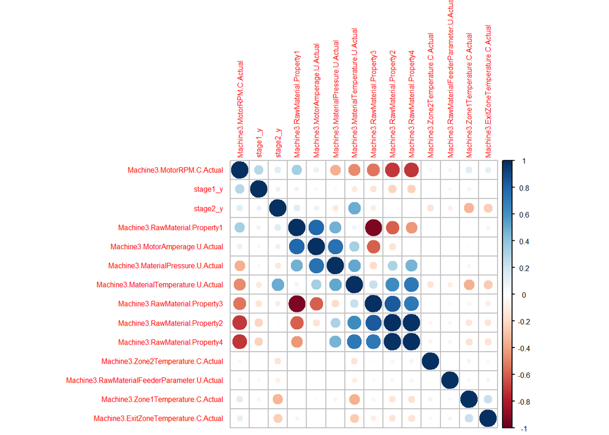

```r
draw_cor_plot(stage1_m3)
```

```
##                                                    FirstStage.CombinerOperation.Temperature1.U.Actual
## FirstStage.CombinerOperation.Temperature1.U.Actual                                        1.000000000
## FirstStage.CombinerOperation.Temperature2.U.Actual                                        0.823370767
## FirstStage.CombinerOperation.Temperature3.C.Actual                                        0.003878389
## stage1_y                                                                                 -0.228764399
## stage2_y                                                                                 -0.143407777
##                                                    FirstStage.CombinerOperation.Temperature2.U.Actual
## FirstStage.CombinerOperation.Temperature1.U.Actual                                         0.82337077
## FirstStage.CombinerOperation.Temperature2.U.Actual                                         1.00000000
## FirstStage.CombinerOperation.Temperature3.C.Actual                                         0.01659892
## stage1_y                                                                                  -0.20716112
## stage2_y                                                                                  -0.49197081
##                                                    FirstStage.CombinerOperation.Temperature3.C.Actual
## FirstStage.CombinerOperation.Temperature1.U.Actual                                        0.003878389
## FirstStage.CombinerOperation.Temperature2.U.Actual                                        0.016598924
## FirstStage.CombinerOperation.Temperature3.C.Actual                                        1.000000000
## stage1_y                                                                                 -0.013234146
## stage2_y                                                                                 -0.004373636
##                                                       stage1_y     stage2_y
## FirstStage.CombinerOperation.Temperature1.U.Actual -0.22876440 -0.143407777
## FirstStage.CombinerOperation.Temperature2.U.Actual -0.20716112 -0.491970814
## FirstStage.CombinerOperation.Temperature3.C.Actual -0.01323415 -0.004373636
## stage1_y                                            1.00000000  0.080429317
## stage2_y                                            0.08042932  1.000000000
```

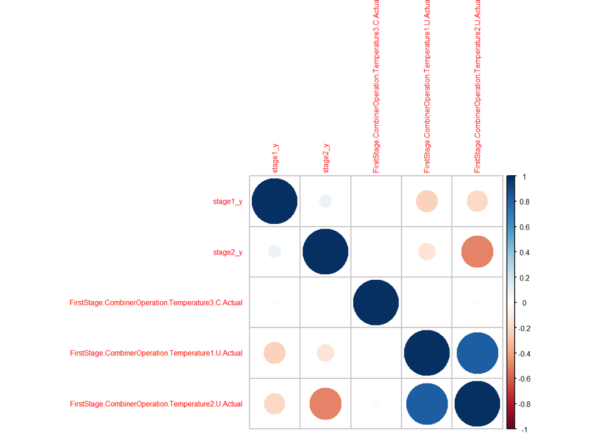

```r
draw_cor_plot(stage1_co)
```

```
##                                   Machine4.Temperature1.C.Actual
## Machine4.Temperature1.C.Actual                        1.00000000
## Machine4.Temperature2.C.Actual                        0.81914130
## Machine4.Pressure.C.Actual                           -0.01012679
## Machine4.Temperature3.C.Actual                        0.08384120
## Machine4.Temperature4.C.Actual                       -0.01012679
## Machine4.Temperature5.C.Actual                        0.34315168
## Machine4.ExitTemperature.U.Actual                    -0.30323164
## stage1_y                                              0.05159169
## stage2_y                                             -0.25607636
##                                   Machine4.Temperature2.C.Actual
## Machine4.Temperature1.C.Actual                         0.8191413
## Machine4.Temperature2.C.Actual                         1.0000000
## Machine4.Pressure.C.Actual                            -0.1249931
## Machine4.Temperature3.C.Actual                         0.1032250
## Machine4.Temperature4.C.Actual                        -0.1249931
## Machine4.Temperature5.C.Actual                         0.3407302
## Machine4.ExitTemperature.U.Actual                     -0.2371160
## stage1_y                                               0.1020805
## stage2_y                                              -0.2002827
##                                   Machine4.Pressure.C.Actual
## Machine4.Temperature1.C.Actual                   -0.01012679
## Machine4.Temperature2.C.Actual                   -0.12499314
## Machine4.Pressure.C.Actual                        1.00000000
## Machine4.Temperature3.C.Actual                    0.22437451
## Machine4.Temperature4.C.Actual                    1.00000000
## Machine4.Temperature5.C.Actual                    0.25535285
## Machine4.ExitTemperature.U.Actual                -0.13214309
## stage1_y                                         -0.17038090
## stage2_y                                         -0.30778789
##                                   Machine4.Temperature3.C.Actual
## Machine4.Temperature1.C.Actual                         0.0838412
## Machine4.Temperature2.C.Actual                         0.1032250
## Machine4.Pressure.C.Actual                             0.2243745
## Machine4.Temperature3.C.Actual                         1.0000000
## Machine4.Temperature4.C.Actual                         0.2243745
## Machine4.Temperature5.C.Actual                         0.8832004
## Machine4.ExitTemperature.U.Actual                      0.5479649
## stage1_y                                              -0.1579816
## stage2_y                                               0.3081382
```

[output cut: 25 more lines]

```
## Machine4.Temperature4.C.Actual                          -0.13214309 -0.17038090
## Machine4.Temperature5.C.Actual                           0.34892190 -0.14525074
## Machine4.ExitTemperature.U.Actual                        1.00000000 -0.06802547
## stage1_y                                                -0.06802547  1.00000000
## stage2_y                                                 0.67236211  0.08042932
##                                      stage2_y
## Machine4.Temperature1.C.Actual    -0.25607636
## Machine4.Temperature2.C.Actual    -0.20028270
## Machine4.Pressure.C.Actual        -0.30778789
## Machine4.Temperature3.C.Actual     0.30813824
## Machine4.Temperature4.C.Actual    -0.30778789
## Machine4.Temperature5.C.Actual     0.18244393
## Machine4.ExitTemperature.U.Actual  0.67236211
## stage1_y                           0.08042932
## stage2_y                           1.00000000
```

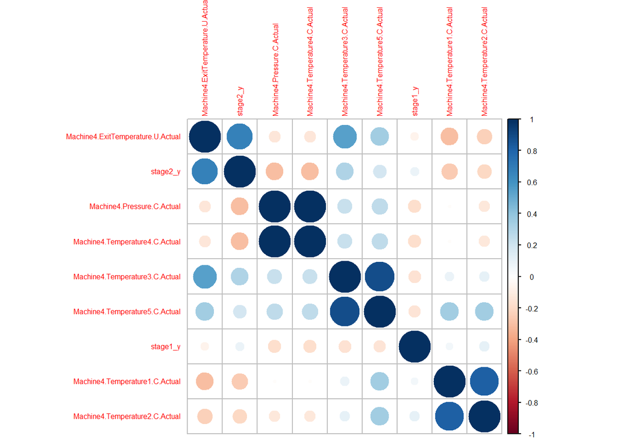

```r
draw_cor_plot(stage2_m4)
```

```
##                                   Machine5.Temperature1.C.Actual
## Machine5.Temperature1.C.Actual                        1.00000000
## Machine5.Temperature2.C.Actual                        0.05839861
## Machine5.Temperature3.C.Actual                        0.11816588
## Machine5.Temperature4.C.Actual                        0.02297597
## Machine5.Temperature5.C.Actual                        0.12421544
## Machine5.Temperature6.C.Actual                       -0.17427620
## Machine5.ExitTemperature.U.Actual                     0.27444595
## stage1_y                                              0.05272196
## stage2_y                                              0.11010808
##                                   Machine5.Temperature2.C.Actual
## Machine5.Temperature1.C.Actual                       0.058398611
## Machine5.Temperature2.C.Actual                       1.000000000
## Machine5.Temperature3.C.Actual                       0.087123785
## Machine5.Temperature4.C.Actual                       0.009114290
## Machine5.Temperature5.C.Actual                      -0.025488803
## Machine5.Temperature6.C.Actual                      -0.142294967
## Machine5.ExitTemperature.U.Actual                    0.090477114
## stage1_y                                             0.009841806
## stage2_y                                             0.076124442
##                                   Machine5.Temperature3.C.Actual
## Machine5.Temperature1.C.Actual                        0.11816588
## Machine5.Temperature2.C.Actual                        0.08712378
## Machine5.Temperature3.C.Actual                        1.00000000
## Machine5.Temperature4.C.Actual                        0.73195971
## Machine5.Temperature5.C.Actual                        0.20822086
## Machine5.Temperature6.C.Actual                       -0.59721286
## Machine5.ExitTemperature.U.Actual                     0.66193056
## stage1_y                                             -0.08518063
## stage2_y                                              0.74284448
##                                   Machine5.Temperature4.C.Actual
## Machine5.Temperature1.C.Actual                        0.02297597
## Machine5.Temperature2.C.Actual                        0.00911429
## Machine5.Temperature3.C.Actual                        0.73195971
## Machine5.Temperature4.C.Actual                        1.00000000
## Machine5.Temperature5.C.Actual                        0.10372604
## Machine5.Temperature6.C.Actual                        0.05585143
## Machine5.ExitTemperature.U.Actual                     0.37798189
## stage1_y                                             -0.32333160
## stage2_y                                              0.28593038
```

[output cut: 25 more lines]

```
## Machine5.Temperature5.C.Actual                           0.41448175
## Machine5.Temperature6.C.Actual                          -0.56804054
## Machine5.ExitTemperature.U.Actual                        1.00000000
## stage1_y                                                 0.01222913
## stage2_y                                                 0.57122908
##                                       stage1_y    stage2_y
## Machine5.Temperature1.C.Actual     0.052721956  0.11010808
## Machine5.Temperature2.C.Actual     0.009841806  0.07612444
## Machine5.Temperature3.C.Actual    -0.085180632  0.74284448
## Machine5.Temperature4.C.Actual    -0.323331601  0.28593038
## Machine5.Temperature5.C.Actual    -0.038641540  0.19747695
## Machine5.Temperature6.C.Actual    -0.191103797 -0.71690512
## Machine5.ExitTemperature.U.Actual  0.012229135  0.57122908
## stage1_y                           1.000000000  0.08042932
## stage2_y                           0.080429317  1.00000000
```

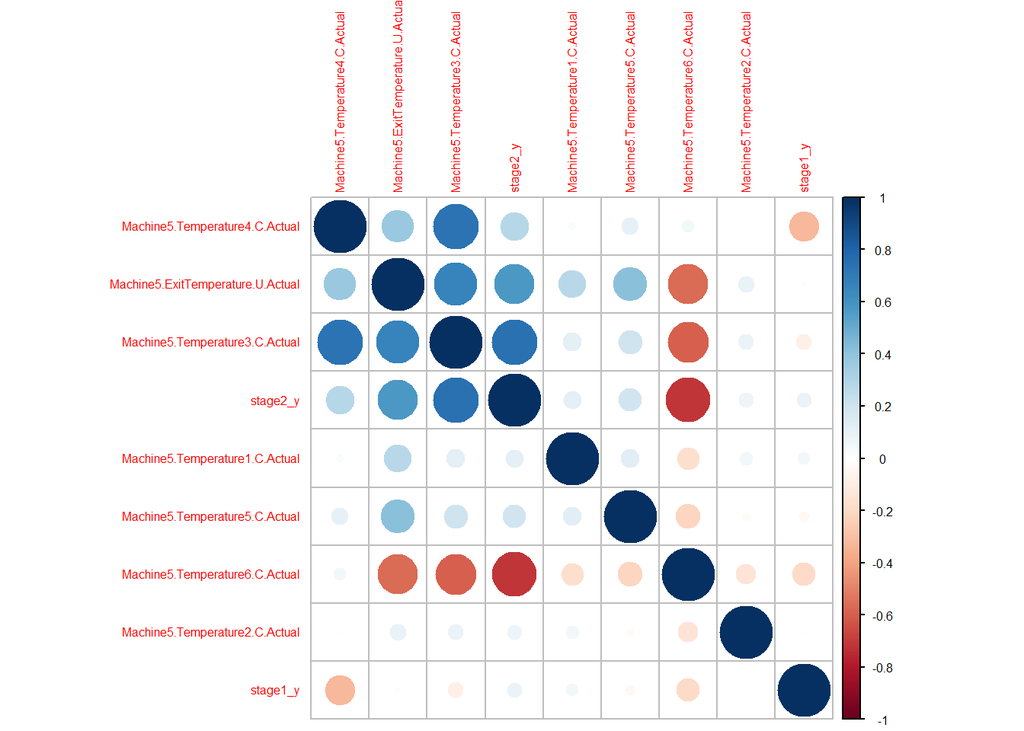

```r
draw_cor_plot(stage2_m5)
```

```r
# 표준편차가 0인 열
std_devs <- apply(dat, 2, sd)
std_0 <- names(std_devs[std_devs == 0])
print(std_0)
```

```
##  [1] NA
##  [2] "Stage2.Output.Measurement0.U.Setpoint"
##  [3] "Stage2.Output.Measurement1.U.Setpoint"
##  [4] "Stage2.Output.Measurement2.U.Setpoint"
##  [5] "Stage2.Output.Measurement3.U.Setpoint"
##  [6] "Stage2.Output.Measurement4.U.Setpoint"
##  [7] "Stage2.Output.Measurement5.U.Setpoint"
##  [8] "Stage2.Output.Measurement6.U.Setpoint"
##  [9] "Stage2.Output.Measurement7.U.Setpoint"
## [10] "Stage2.Output.Measurement8.U.Setpoint"
## [11] "Stage2.Output.Measurement9.U.Setpoint"
## [12] "Stage2.Output.Measurement10.U.Setpoint"
## [13] "Stage2.Output.Measurement11.U.Setpoint"
## [14] "Stage2.Output.Measurement12.U.Setpoint"
## [15] "Stage2.Output.Measurement13.U.Setpoint"
## [16] "Stage2.Output.Measurement14.U.Setpoint"
```

```r
drop_list <- std_0[2:16]

col_list <- c(stage1_m1, stage1_m2, stage1_m3, stage1_co, stage2_m4, stage2_m5)
final_data <- dat[,c(col_list,"stage1_y", "stage2_y")]

set.seed(0)

trainidx <- sample(1:nrow(final_data), 0.8*nrow(final_data))
trainset <- final_data[trainidx,]
testset <- final_data[-trainidx,]

colnames(trainset)
```

```
##  [1] "Machine1.RawMaterial.Property1"
##  [2] "Machine1.RawMaterial.Property2"
##  [3] "Machine1.RawMaterial.Property3"
##  [4] "Machine1.RawMaterial.Property4"
##  [5] "Machine1.RawMaterialFeederParameter.U.Actual"
##  [6] "Machine1.Zone1Temperature.C.Actual"
##  [7] "Machine1.Zone2Temperature.C.Actual"
##  [8] "Machine1.MotorAmperage.U.Actual"
##  [9] "Machine1.MotorRPM.C.Actual"
## [10] "Machine1.MaterialPressure.U.Actual"
## [11] "Machine1.MaterialTemperature.U.Actual"
## [12] "Machine1.ExitZoneTemperature.C.Actual"
## [13] "Machine2.RawMaterial.Property1"
## [14] "Machine2.RawMaterial.Property2"
## [15] "Machine2.RawMaterial.Property3"
```

[output cut: 40 more lines]

```r
scaling <- preProcess(trainset[,-ncol(trainset)],
                      method = c('center','scale'))
trainsc <- predict(scaling, trainset[,-ncol(trainset)])
testsc <- predict(scaling, testset[,-ncol(testset)])

trainsc$stage1_y <- trainset$stage1_y
testsc$stage2_y <- testset$stage2_y
```

### 2. 특징 추출 및 차원 축소

- 전처리가 이루어진 데이터로부터 특성을 재정의하거나 차원 축소 기법을 적용
- 신규 변수 또는 축소된 차원으로 효과적인 예측을 수행하기 위한 방안 도출

### 3. 모델 학습 및 평가

- Stage 1, Stage 2에 대한 예측 모델을 수립할 것
- 이 때, 각 Stage는 연결되어 있으며 Stage 2는 Stage 1의 영향을 받음